# zadanie3_bagin.R

samuelbagin

2026-10-20

# zadanie 3

Samuel Bagin

```r
library(readxl)
library(ggplot2)
library(viridisLite)
library(latexpdf)

alfa <- 0.05
farby <- viridis(4, end = 0.8)
farby_hranic <- viridis(2, begin = 0.05, end = 0.65)
nazvy_modelov <- c("Eurokod", "MC LoAI", "MC LoAII", "MC LoAIII")
```

# 1. import a uprava dat

```r
cesty_skriptov <- c(
  sub("^--file=", "", grep("^--file=", commandArgs(), value = TRUE)),
  unlist(lapply(sys.frames(), function(ramec) ramec$ofile), use.names = FALSE)
)
priecinok <- if (length(cesty_skriptov) > 0) {
  dirname(normalizePath(tail(cesty_skriptov, 1)))
} else {
  getwd()
}
subor_dat <- file.path(priecinok, "Modely_pretlacenie.xlsx")

data <- as.data.frame(read_xlsx(subor_dat, sheet = "data"))
str(data)
```

```
## 'data.frame':    55 obs. of  8 variables:
##  $ Eurokod  : num  0.727 1.087 0.751 0.73 0.892 ...
##  $ Eexp     : num  0.691 0.842 0.911 0.913 1.013 ...
##  $ MCLoAI   : num  0.812 1.006 1.238 1.362 0.717 ...
##  $ LoAIexp  : num  0.926 1.381 1.478 1.495 0.99 ...
##  $ MCLoAII  : num  1.205 1.961 1.147 0.791 1.456 ...
##  $ LoAIIexp : num  0.948 1.2 1.039 1.248 1.122 ...
##  $ MCLoAIII : num  1.054 1.022 0.966 0.834 0.983 ...
##  $ LoAIIIexp: num  1.287 1.484 1.17 1.229 0.877 ...
```

```r
head(data)
```

```
##     Eurokod      Eexp    MCLoAI   LoAIexp   MCLoAII  LoAIIexp  MCLoAIII
## 1 0.7272645 0.6911456 0.8121581 0.9258595 1.2048186 0.9484956 1.0537680
## 2 1.0872435 0.8415144 1.0056235 1.3812699 1.9606755 1.1997284 1.0220904
## 3 0.7513428 0.9109646 1.2382006 1.4782955 1.1466549 1.0389567 0.9657635
## 4 0.7296875 0.9133536 1.3615373 1.4951647 0.7914542 1.2480748 0.8341171
## 5 0.8917774 1.0127715 0.7173326 0.9896331 1.4558157 1.1221532 0.9830618
## 6 0.9867384 1.1650344 1.3481921 1.4167379 0.9981541 1.3295007 0.9751405
##   LoAIIIexp
## 1 1.2868250
## 2 1.4837336
## 3 1.1696305
## 4 1.2291976
## 5 0.8773447
## 6 1.3628513
```

```r
colSums(is.na(data))
```

```
##   Eurokod      Eexp    MCLoAI   LoAIexp   MCLoAII  LoAIIexp  MCLoAIII LoAIIIexp
##         0         0         0         0         0         0         0         0
```

```r
sum(duplicated(data))
```

```
## [1] 0
```

```r
stlpce <- c("Eurokod", "Eexp", "MCLoAI", "LoAIexp",
            "MCLoAII", "LoAIIexp", "MCLoAIII", "LoAIIIexp")

hodnoty <- as.matrix(data[stlpce])
```

data obsahuju 55 riadkov a 8 ciselnych stlpcov bez chybajucich hodnot a zhodnych riadkov. kazdy model ma vlastny stlpec modelovych aj experimentalnych hodnot.

```r
View(data)

podiely <- data.frame(
  Eurokod = data$Eexp / data$Eurokod,
  MCLoAI = data$LoAIexp / data$MCLoAI,
  MCLoAII = data$LoAIIexp / data$MCLoAII,
  MCLoAIII = data$LoAIIIexp / data$MCLoAIII
)
head(podiely)
```

```
##     Eurokod   MCLoAI   MCLoAII  MCLoAIII
## 1 0.9503359 1.139999 0.7872518 1.2211653
## 2 0.7739889 1.373546 0.6118954 1.4516657
## 3 1.2124487 1.193906 0.9060762 1.2110941
## 4 1.2517051 1.098144 1.5769388 1.4736511
## 5 1.1356775 1.379601 0.7708072 0.8924614
## 6 1.1806923 1.050843 1.3319593 1.3975949
```

podiel $x = V_{exp} / V_{model}$, hodnota pod 1 znamena nadhodnotenie odolnosti modelom. riadky v ramci dvojice zostavaju sparovane, nepouzivame podiel priemerov stlpcov.

```r
dlhe_data <- data.frame(
  model = factor(rep(nazvy_modelov, each = nrow(podiely)), levels = nazvy_modelov),
  podiel = unlist(podiely, use.names = FALSE)
)
popis <- do.call(rbind, lapply(podiely, function(x) {
  data.frame(n = length(x), priemer = mean(x), median = median(x),
             sd = sd(x), rozptyl = var(x), minimum = min(x), maximum = max(x),
             pod_1 = sum(x < 1), podiel_pod_1 = mean(x < 1))
}))
popis
```

```
##           n  priemer   median        sd    rozptyl   minimum  maximum pod_1
## Eurokod  55 1.189803 1.202161 0.1670597 0.02790893 0.7739889 1.518482     8
## MCLoAI   55 1.177968 1.156276 0.1017687 0.01035687 1.0007262 1.379601     0
## MCLoAII  55 1.118222 1.126886 0.2519642 0.06348596 0.5005004 1.746068    16
## MCLoAIII 55 1.201342 1.211094 0.2538193 0.06442423 0.7056382 1.803013    16
##          podiel_pod_1
## Eurokod     0.1454545
## MCLoAI      0.0000000
## MCLoAII     0.2909091
## MCLoAIII    0.2909091
```

priemery: Eurokod 1,18980, MC LoAI 1,17797, MC LoAII 1,11822 a MC LoAIII 1,20134. podiel pod 1 ma Eurokod v 8 pripadoch, MC LoAI v 0, MC LoAII v 16 a MC LoAIII v 16. vsetky pozorovane pripady su bezpecne iba pri MC LoAI, jeho minimum je 1,00073.

# 2. priklad 1 - graficka struktura a bezpecnost modelov

## rozdelenie podielov

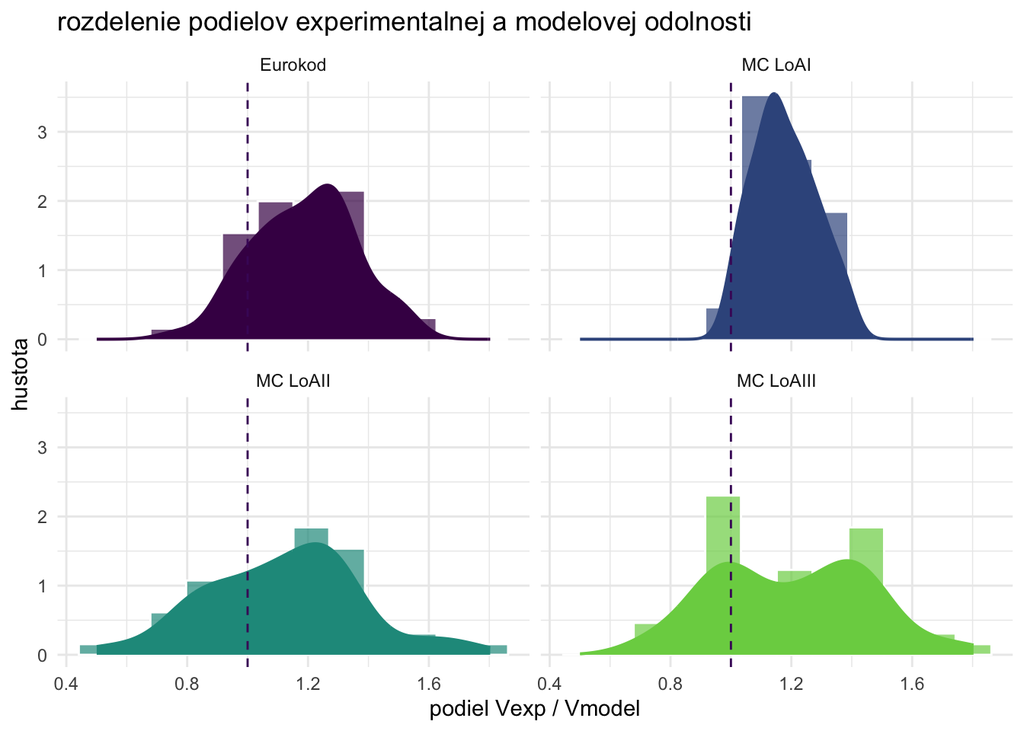

```r
graf_histogram <- ggplot(dlhe_data, aes(podiel, fill = model)) +
  geom_histogram(aes(y = after_stat(density)), bins = 12, color = "white", alpha = 0.7) +
  geom_density(aes(color = model), linewidth = 0.7) +
  geom_vline(xintercept = 1, color = farby_hranic[1], linetype = 2) +
  facet_wrap(~ model, ncol = 2) +
  scale_fill_manual(values = farby, guide = "none") +
  scale_color_manual(values = farby, guide = "none") + theme_minimal() +
  labs(title = "rozdelenie podielov experimentalnej a modelovej odolnosti",
       x = "podiel Vexp / Vmodel", y = "hustota")
print(graf_histogram)
```

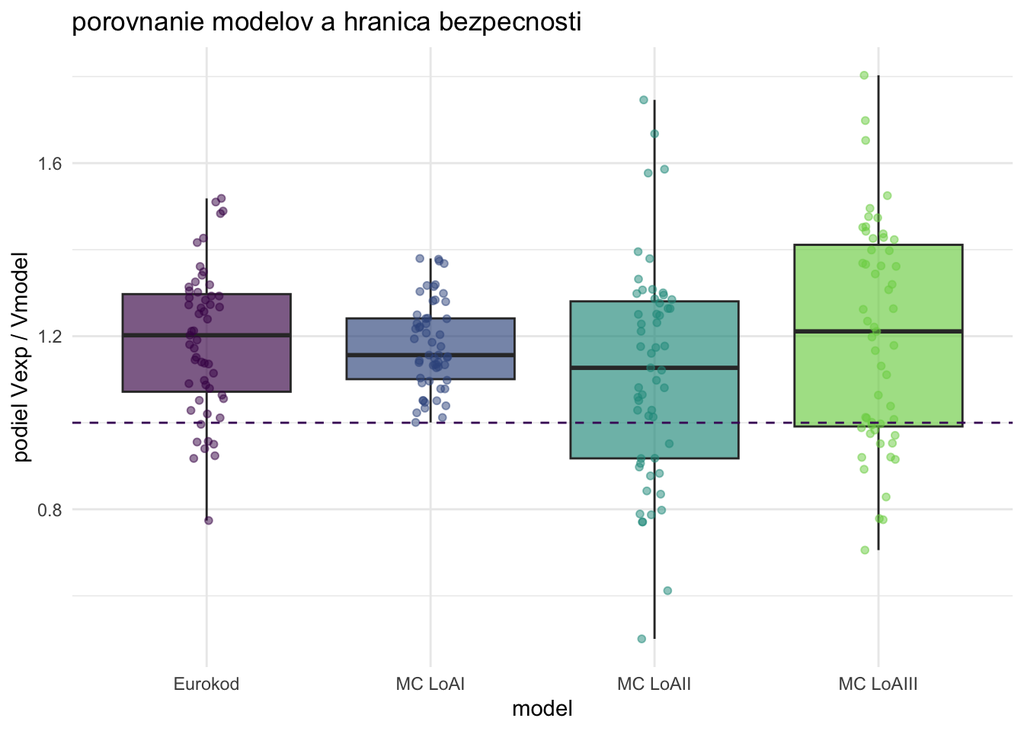

```r
graf_boxplot <- ggplot(dlhe_data, aes(model, podiel, fill = model)) +
  geom_boxplot(alpha = 0.65, outlier.shape = NA) +
  geom_point(aes(color = model), position = position_jitter(width = 0.08, height = 0, seed = 2026),
             alpha = 0.5, size = 1.4) +
  geom_hline(yintercept = 1, color = farby_hranic[1], linetype = 2) +
  scale_fill_manual(values = farby, guide = "none") +
  scale_color_manual(values = farby, guide = "none") + theme_minimal() +
  labs(title = "porovnanie modelov a hranica bezpecnosti", x = "model", y = "podiel Vexp / Vmodel")
print(graf_boxplot)
```

MC LoAI ma najmensi rozptyl a jeho body lezia nad hranicou 1. MC LoAII ma priemer najblizsie k 1, ale spolu s MC LoAIII vykazuje najvacsiu variabilitu. odlahle hodnoty automaticky neodstranujeme, pretoze nemame dokaz chyby merania.

## predpoklady testov

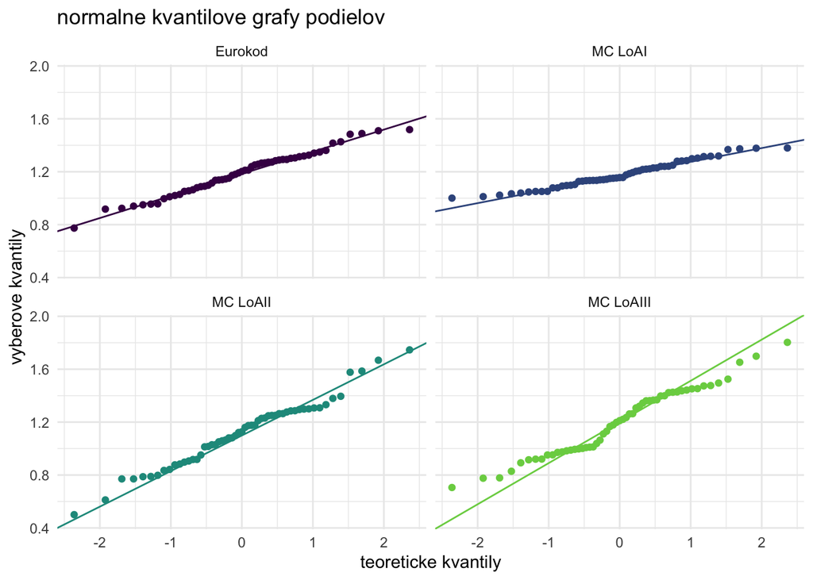

```r
graf_qq <- ggplot(dlhe_data, aes(sample = podiel, color = model)) +
  stat_qq(size = 1.5) + stat_qq_line() + facet_wrap(~ model, ncol = 2) +
  scale_color_manual(values = farby, guide = "none") + theme_minimal() +
  labs(title = "normalne kvantilove grafy podielov", x = "teoreticke kvantily", y = "vyberove kvantily")
print(graf_qq)
```

```r
normalita <- do.call(rbind, lapply(podiely, function(x) {
  test <- shapiro.test(x)
  data.frame(W = unname(test$statistic), p = test$p.value)
}))
normalita
```

```
##                  W         p
## Eurokod  0.9841417 0.6798596
## MCLoAI   0.9679646 0.1490155
## MCLoAII  0.9800754 0.4911346
## MCLoAIII 0.9673975 0.1404507
```

zadanie predpoklada normalne rozdelenie podielov, Q-Q grafy a Shapirov-Wilkov test ho doplnkovo kontroluju. p-hodnoty su 0,67986, 0,14902, 0,49113 a 0,14045, preto normalitu na hladine 0,05 nezamietame. nezamietnutie nie je dokaz normality. Dalej predpokladame nezavisle skusky v ramci kazdeho modelu; tento predpoklad nemozno overit iba z dodanej tabulky. Medzi modelmi nezavislost nevyzadujeme, pretoze testujeme kazdy model osobitne a nerobime dvojvyberove porovnania.

## jednostranny jednovyberovy t-test

pre kazdy model: $H_0: \mu ≤ 1 \qquad H_1: \mu > 1$, kde $\mu$ je stredna hodnota podielu. hranicny pripad H_0 je $\mu = 1$. Testujeme na hladine $\alpha = 0,05$. testova statistika: $t = (priemer - 1) / (s / \sqrt{n})$, pri hranici $H_0$ ma $n - 1$ stupnov volnosti.

```r
testy_priemeru <- lapply(podiely, function(x) {
  stats::t.test(x, mu = 1, alternative = "greater", conf.level = 1 - alfa)
})
testy_priemeru
```

```
## $Eurokod
##
##  One Sample t-test
##
## data:  x
## t = 8.4259, df = 54, p-value = 1.019e-11
## alternative hypothesis: true mean is greater than 1
## 95 percent confidence interval:
##  1.152104      Inf
## sample estimates:
## mean of x
##  1.189803
##
##
## $MCLoAI
##
##  One Sample t-test
##
## data:  x
## t = 12.969, df = 54, p-value < 2.2e-16
## alternative hypothesis: true mean is greater than 1
## 95 percent confidence interval:
##  1.155002      Inf
## sample estimates:
## mean of x
##  1.177968
##
##
## $MCLoAII
##
##  One Sample t-test
##
## data:  x
## t = 3.4797, df = 54, p-value = 0.0005005
## alternative hypothesis: true mean is greater than 1
## 95 percent confidence interval:
##  1.061363      Inf
## sample estimates:
## mean of x
##  1.118222
##
##
## $MCLoAIII
##
##  One Sample t-test
##
## data:  x
## t = 5.8829, df = 54, p-value = 1.313e-07
## alternative hypothesis: true mean is greater than 1
## 95 percent confidence interval:
##  1.144064      Inf
## sample estimates:
## mean of x
##  1.201342
```

```r
bezpecnost <- do.call(rbind, lapply(testy_priemeru, function(test) {
  data.frame(priemer = unname(test$estimate), t = unname(test$statistic),
             df = unname(test$parameter), p = test$p.value,
             dolna_95 = test$conf.int[1], horna_95 = test$conf.int[2])
}))
bezpecnost$rozhodnutie <- ifelse(bezpecnost$p < alfa, "zamietame H0: priemer je nad 1", "H0 nezamietame")
bezpecnost
```

```
##           priemer         t df            p dolna_95 horna_95
## Eurokod  1.189803  8.425853 54 1.019408e-11 1.152104      Inf
## MCLoAI   1.177968 12.969073 54 1.597404e-18 1.155002      Inf
## MCLoAII  1.118222  3.479694 54 5.004904e-04 1.061363      Inf
## MCLoAIII 1.201342  5.882896 54 1.313014e-07 1.144064      Inf
##                             rozhodnutie
## Eurokod  zamietame H0: priemer je nad 1
## MCLoAI   zamietame H0: priemer je nad 1
## MCLoAII  zamietame H0: priemer je nad 1
## MCLoAIII zamietame H0: priemer je nad 1
```

p-hodnoty: Eurokod 1,019e-11, MC LoAI 1,597e-18, MC LoAII 0,0005005, MC LoAIII 1,313e-7. pri vsetkych styroch modeloch zamietame $H_0$ v prospech $\mu > 1$: modely su bezpecne v priemere. dolne jednostranne $95 %$ hranice priemeru su 1,15210, 1,15500, 1,06136 a 1,14406. t-test priemeru nezarucuje, ze kazdy podiel je aspon 1, v troch modeloch uz data ukazuju opak. ani 55 bezpecnych pozorovani pri MC LoAI nezarucuje bezpecnost vsetkych buducich skusok.

## intervaly priemerov pre graficke porovnanie

v grafe su konecne obojstranne 95 % intervaly, jednostranne intervaly vyssie maju hornu hranicu Inf.

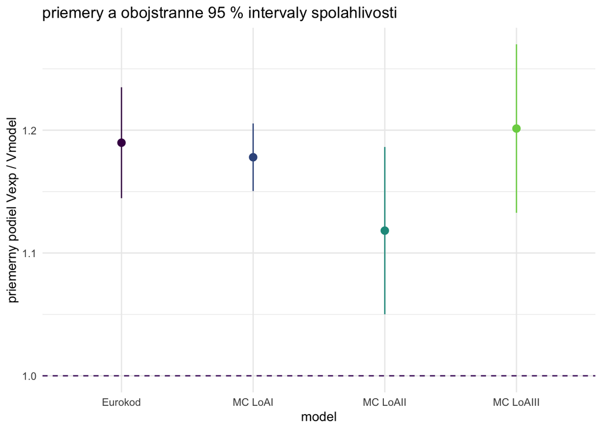

```r
intervaly_priemeru <- do.call(rbind, lapply(podiely, function(x) {
  ci <- stats::t.test(x, conf.level = 1 - alfa)$conf.int
  data.frame(priemer = mean(x), dolna = ci[1], horna = ci[2])
}))
intervaly_priemeru$model <- factor(nazvy_modelov, levels = nazvy_modelov)
graf_priemerov <- ggplot(intervaly_priemeru, aes(model, priemer, ymin = dolna, ymax = horna, color = model)) +
  geom_pointrange() + geom_hline(yintercept = 1, color = farby_hranic[1], linetype = 2) +
  scale_color_manual(values = farby, guide = "none") + theme_minimal() +
  labs(title = "priemery a obojstranne 95 % intervaly spolahlivosti",
       x = "model", y = "priemerny podiel Vexp / Vmodel")
print(graf_priemerov)
```

z hladiska bezpecnosti, presnosti a malej variability sa najlepsie javi MC LoAI. MC LoAII je priemerom blizsie k 1, no ma 16 pozorovani pod 1 a vyrazne vacsi rozptyl.

# 3. priklad 2 - konzistentnost modelov

```r
test_rozptylu <- function(x, sigma2_0, alternativa = c("greater", "less", "two.sided")) {
  alternativa <- match.arg(alternativa)
  df <- length(x) - 1
  chi2 <- df * var(x) / sigma2_0
  p_dolna <- pchisq(chi2, df = df)
  p_horna <- pchisq(chi2, df = df, lower.tail = FALSE)
  p <- switch(alternativa, greater = p_horna, less = p_dolna,
              two.sided = min(1, 2 * min(p_dolna, p_horna)))
  data.frame(rozptyl = var(x), sigma2_0 = sigma2_0, chi2 = chi2, df = df, p = p)
}
```

## nutna poziadavka - rozptyl nema presiahnut 0,05

pre kazdy model: $H_0: \sigma^2 ≤ 0,05, \qquad H_1: \sigma^2 > 0,05 \qquad \alpha = 0,05$. tento pravostranny test zistuje, ci vieme preukazat prekrocenie povoleneho rozptylu.

```r
testy_nutne <- do.call(rbind, lapply(podiely, test_rozptylu, sigma2_0 = 0.05, alternativa = "greater"))
kriticka_nutna <- qchisq(1 - alfa, df = testy_nutne$df)
testy_nutne$kriticka_hodnota <- kriticka_nutna
testy_nutne$rozhodnutie <- ifelse(testy_nutne$p < alfa, "zamietame H0: rozptyl presahuje 0,05", "H0 nezamietame")
testy_nutne
```

```
##             rozptyl sigma2_0     chi2 df          p kriticka_hodnota
## Eurokod  0.02790893     0.05 30.14165 54 0.99647927         72.15322
## MCLoAI   0.01035687     0.05 11.18542 54 1.00000000         72.15322
## MCLoAII  0.06348596     0.05 68.56484 54 0.08769125         72.15322
## MCLoAIII 0.06442423     0.05 69.57817 54 0.07522924         72.15322
##             rozhodnutie
## Eurokod  H0 nezamietame
## MCLoAI   H0 nezamietame
## MCLoAII  H0 nezamietame
## MCLoAIII H0 nezamietame
```

p-hodnoty su 0,99648 priblizne 1, 0,08769 a 0,07523. $H_0$ nezamietame pri ziadnom modeli. prekrocenie 0,05 sa teda na hladine 0,05 nepreukazalo, ale to este nepotvrdzuje splnenie poziadavky. vyberove rozptyly MC LoAII 0,06349 a MC LoAIII 0,06442 uz prevysuju odporucanu hranicu.

## doplnkove overenie splnenia nutnej poziadavky

pre kazdy model: $H_0: \sigma^2 ≥ 0,05 \qquad H_1: \sigma^2 < 0,05 \qquad \alpha = 0,05$. tento lavostranny test umoznuje priamo podlozit, ze rozptyl lezi pod povolenou hranicou.

```r
testy_splnenia <- do.call(rbind, lapply(podiely, test_rozptylu, sigma2_0 = 0.05, alternativa = "less"))
testy_splnenia$horna_95 <- (testy_splnenia$df * testy_splnenia$rozptyl /
                          qchisq(alfa, df = testy_splnenia$df))
testy_splnenia$rozhodnutie <- ifelse(testy_splnenia$p < alfa, "rozptyl pod 0,05 je podlozeny", "splnenie nie je preukazane")
testy_splnenia
```

```
##             rozptyl sigma2_0     chi2 df            p   horna_95
## Eurokod  0.02790893     0.05 30.14165 54 3.520735e-03 0.03953914
## MCLoAI   0.01035687     0.05 11.18542 54 6.543371e-11 0.01467278
## MCLoAII  0.06348596     0.05 68.56484 54 9.123087e-01 0.08994182
## MCLoAIII 0.06442423     0.05 69.57817 54 9.247708e-01 0.09127108
##                            rozhodnutie
## Eurokod  rozptyl pod 0,05 je podlozeny
## MCLoAI   rozptyl pod 0,05 je podlozeny
## MCLoAII     splnenie nie je preukazane
## MCLoAIII    splnenie nie je preukazane
```

Eurokod: p = 0,00352, horna jednostranna 95 % hranica rozptylu 0,03954. MC LoAI: p = 6,543e-11, horna hranica 0,01467. Pri oboch je rozptyl pod 0,05 podlozeny. pri MC LoAII a MC LoAIII su p-hodnoty 0,91231 a 0,92477, splnenie poziadavky nevieme preukazat.

## idealna poziadavka - rozptyl 0,01

pre kazdy model: $H_0: \sigma^2 = 0,01 \qquad H_1: \sigma^2 ≠ 0,01 \qquad \alpha = 0,05$. slovo idealne interpretujeme ako rovnost s 0,01, preto pouzivame obojstranny test.

```r
testy_idealne <- do.call(rbind, lapply(podiely, test_rozptylu, sigma2_0 = 0.01, alternativa = "two.sided"))
testy_idealne$kriticka_dolna <- qchisq(alfa / 2, df = testy_idealne$df)
testy_idealne$kriticka_horna <- qchisq(1 - alfa / 2, df = testy_idealne$df)
testy_idealne$rozhodnutie <- ifelse(testy_idealne$p < alfa, "zamietame H0: rozptyl sa lisi od 0,01", "H0 nezamietame")
testy_idealne
```

```
##             rozptyl sigma2_0      chi2 df            p kriticka_dolna
## Eurokod  0.02790893     0.01 150.70825 54 8.989629e-11       35.58634
## MCLoAI   0.01035687     0.01  55.92708 54 8.046837e-01       35.58634
## MCLoAII  0.06348596     0.01 342.82419 54 2.559042e-43       35.58634
## MCLoAIII 0.06442423     0.01 347.89083 54 2.967695e-44       35.58634
##          kriticka_horna                           rozhodnutie
## Eurokod        76.19205 zamietame H0: rozptyl sa lisi od 0,01
## MCLoAI         76.19205                        H0 nezamietame
## MCLoAII        76.19205 zamietame H0: rozptyl sa lisi od 0,01
## MCLoAIII       76.19205 zamietame H0: rozptyl sa lisi od 0,01
```

p-hodnoty su 8,990e-11, 0,80468, 2,559e-43 a 2,968e-44. iba pri MC LoAI nezamietame idealny rozptyl 0,01 a jeho vyberovy rozptyl je 0,01036. pri ostatnych modeloch $H_0$ zamietame a pozorovane rozptyly su vyssie ako 0,01. nezamietnutie rovnosti pri MC LoAI neznamena dokaz presnej rovnosti rozptylu s 0,01.

## intervaly rozptylov

```r
intervaly_rozptylu <- do.call(rbind, lapply(podiely, function(x) {
  df <- length(x) - 1
  data.frame(rozptyl = var(x), dolna = df * var(x) / qchisq(1 - alfa / 2, df),
             horna = df * var(x) / qchisq(alfa / 2, df))
}))
intervaly_rozptylu$model <- factor(nazvy_modelov, levels = nazvy_modelov)
intervaly_rozptylu
```

```
##             rozptyl       dolna      horna     model
## Eurokod  0.02790893 0.019780049 0.04235003   Eurokod
## MCLoAI   0.01035687 0.007340277 0.01571588   MC LoAI
## MCLoAII  0.06348596 0.044994747 0.09633589  MC LoAII
## MCLoAIII 0.06442423 0.045659729 0.09775965 MC LoAIII
```

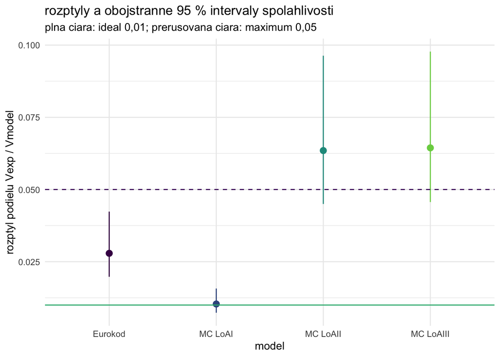

```r
graf_rozptylov <- ggplot(intervaly_rozptylu, aes(model, rozptyl, ymin = dolna, ymax = horna, color = model)) +
  geom_pointrange() +
  geom_hline(yintercept = 0.01, color = farby_hranic[2], linetype = 1) +
  geom_hline(yintercept = 0.05, color = farby_hranic[1], linetype = 2) +
  scale_color_manual(values = farby, guide = "none") + theme_minimal() +
  labs(title = "rozptyly a obojstranne 95 % intervaly spolahlivosti",
       subtitle = "plna ciara: ideal 0,01; prerusovana ciara: maximum 0,05",
       x = "model", y = "rozptyl podielu Vexp / Vmodel")
print(graf_rozptylov)
```

obojstranne intervaly: Eurokod (0,01978, 0,04235), MC LoAI (0,00734, 0,01572), MC LoAII (0,04499, 0,09634), MC LoAIII (0,04566, 0,09776). posledne dva intervaly obsahuju 0,05, preto z tychto dat nemame jednoznacny zaver o prekroceni hranice.

# zaver

vsetky styri modely maju statisticky preukazany priemerny podiel nad 1. poziadavku bezpecnosti v kazdej jednotlivej skuske vsak v dodanych datach splna iba MC LoAI. Eurokod aj MC LoAI maju podlozeny rozptyl pod 0,05, iba MC LoAI je zlucitelny s idealnym rozptylom 0,01. MC LoAI preto predstavuje najlepsi kompromis bezpecnosti, presnosti a konzistentnosti v tychto datach. pri MC LoAII a MC LoAIII je vyberovy rozptyl nad limitom, no jeho prekrocenie nie je na hladine 0,05 preukazane. testy hodnotime samostatne na hladine 0,05 pre kazdy model, bez korekcie na viacnasobne testovanie.